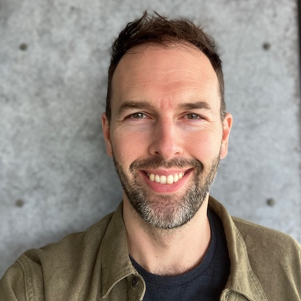

# Tom Hardwicke

## Publications

#### Preprints

Galet-Lalande, I., Blackwell, J. C., & Hardwicke, T. E. (preprint). Open science in a contentious field: How transparent is research on social media and adolescent mental health? *PsyArXiv*.  
[preprint](https://doi.org/10.31234/osf.io/xcuge_v1) [preregistration](https://doi.org/10.17605/OSF.IO/7UQZ6) [materials](https://doi.org/10.5281/zenodo.21484156) [data](https://doi.org/10.5281/zenodo.21484156) [analysis-code](https://doi.org/10.5281/zenodo.21484156) [reproducible-container](https://doi.org/10.24433/CO.9091637.V1)

Kotoulas, B., Blackwell, J. C., & Hardwicke, T. E. (preprint). Has transparency improved in clinical psychology? A repeated cross-sectional study (2012, 2018, 2024). *PsyArXiv*.  
[preprint](https://doi.org/10.31234/osf.io/jn435_v1) [preregistration](https://doi.org/10.17605/OSF.IO/68VJN) [materials](https://doi.org/10.5281/zenodo.18883852) [data](https://doi.org/10.5281/zenodo.18883852) [analysis-code](https://doi.org/10.5281/zenodo.18883852) [reproducible-container](https://doi.org/10.24433/CO.2378849.V2)

Hardwicke, T. E. (preprint). Risk of bias in robustness reports. *MetaArXiv*.  
[preprint](https://doi.org/10.31222/osf.io/wj26e_v2)

Fernández, L. M., Hardwicke, T. E., & Vadillo, M. A. (preprint). Retracted papers clinging on to life: An observational study of post-retraction citations in psychology. *PsyArXiv*.  
[preprint](https://doi.org/hcht) [data](https://osf.io/t73rk/) [analysis-code](https://osf.io/t73rk/)

#### 2026

Reiss, M. V., …Hardwicke, T. E…. Roggenkamp, H. (2026). Improving computational reproducibility in the social sciences. *Nature Human Behaviour*.  
[paper](https://rdcu.be/gqvVA7iZHYma)

#### 2025

Whamond, A., Vazire, S., Clarke, B., Moodie, N., Schiavone, S., Thibault, R. T., Hardwicke, T. E. (2025). How do psychology journals handle post-publication critique? A cross-sectional study of policy and practice. *Advances in Methods and Practices in Psychological Science*, *8*(3).  
[paper](https://doi.org/10.1177/25152459251366102) [preprint](https://doi.org/10.31234/osf.io/eadhb) [preregistration](https://osf.io/nqj7b) [materials](https://osf.io/8k7m4/) [data](https://osf.io/z4h72/files/osfstorage) [analysis-code](https://osf.io/z4h72/files/osfstorage) [reproducible-container](https://doi.org/10.24433/CO.3949618.v1)

Sandoval-Lentisco, A., Tortajada, M., López-Nicolás, R., López-López, J. A., Wagenmakers, E.J., Sánchez-Meca, J., & Hardwicke, T. E. (2025). Preregistration of psychology meta-analyses: A cross-sectional study of prevalence and practice. *Advances in Methods and Practices in Psychological Science*. *8*(1).  
[paper](https://doi.org/10.1177/25152459241300113) [preprint](https://osf.io/preprints/metaarxiv/627a4) [preregistration](https://osf.io/rnv5c) [materials](https://osf.io/ru5h4/) [data](https://osf.io/ru5h4/) [analysis-code](https://osf.io/ru5h4/)

Frank, M. C., Braginsky, M., Cachia, J., Coles, N., Hardwicke, T. E., Hawkins, R., Mathur, M., & Williams, R. (2025). Experimentology: An open science approach to experimental psychology methods. MIT Press.  
[open access book](https://doi.org/10.25936/3JP6-5M50)

#### 2024

Hardwicke, T. E., Thibault, R. T., Clarke, B., Moodie, N., Crüwell, S., Schiavone, S. R., Handcock, S. A., Nghiem, K. A., Mody, F., Erole, T., & Vazire, S. (2024). Prevalence of transparent research practices in psychology: A cross-sectional study of empirical articles published in 2022. *Advances in Methods and Practices in Psychological Science*, *7*(4).  
[paper](https://doi.org/10.1177/25152459241283477) [preprint](https://osf.io/preprints/psyarxiv/t2zs9) [preregistration](https://osf.io/xh6mg) [materials](https://osf.io/zk97j/files/osfstorage) [data](https://osf.io/zk97j/files/osfstorage) [analysis-code](https://osf.io/zk97j/files/osfstorage) [reproducible-container](https://doi.org/10.24433/CO.5081898.v2)

Hardwicke, T. E. & Vazire, S. (2024). Open science. In Frank, M. C. & Majid, A. (Eds). *The Open Encyclopedia of Cognitive Science*. MIT Press.  
[open access book chapter](https://doi.org/10.21428/e2759450.cdacaf45)

Hardwicke, T. E., Schiavone, S. R., Clarke, B., & Vazire, S. (2024). An empirical appraisal of eLife’s assessment vocabulary [Registered Report]. *PLOS Biology*, *22*(8), e3002645.  
[paper](https://doi.org/10.1371/journal.pbio.3002645) [preprint](https://doi.org/10.1101/2024.04.30.591844) [preregistration](https://doi.org/10.17605/OSF.IO/MKBTP) [materials](https://osf.io/mw2q4/files/osfstorage) [data](https://osf.io/mw2q4/files/osfstorage) [analysis-code](https://osf.io/mw2q4/files/osfstorage) [reproducible-container](https://doi.org/10.24433/CO.4128032.v1)

Dulitzki, C., Crane, S. M., Hardwicke, T. E., & Ioannidis, J. P. A. (2024). Expanding the Data Ark: An attempt to make the data from highly cited social science papers publicly available. *Royal Society Open Science*, *11*(5), 240016.  
[paper](https://doi.org/10.1098/rsos.240016) [preprint](https://osf.io/preprints/metaarxiv/w9crz/) [preregistration](https://osf.io/697wx) [materials](https://osf.io/3kuwq/) [data](https://osf.io/3kuwq/) [analysis-code](https://osf.io/3kuwq/) [reproducible-container](https://doi.org/10.24433/CO.5136309.v2)

Hardwicke, T. E., & Vazire, S. (2024). Transparency is now the default at Psychological Science [editorial]. *Psychological Science*, *35*(7), 703-824.  
[paper](https://doi.org/10.1177/09567976231221573)

#### 2023

Thibault, R. T., Kovacs, M., Hardwicke, T. E., Sarafoglou, A., Ioannidis, J. P., & Munafo, M. R. (2023). Reducing bias in secondary data analysis via an Explore and Confirm Analysis Workflow (ECAW): A proposal and survey of observational researchers. *Royal Society Open Science*, *10*, 230568.  
[paper](https://doi.org/10.1098/rsos.230568) [preprint](https://doi.org/10.31222/osf.io/md2xz) [preregistration](https://osf.io/g2fw5) [materials](https://osf.io/x2dpn) [data](https://osf.io/x2dpn) [analysis-code](https://osf.io/x2dpn)

Hardwicke, T. E., & Wagenmakers, E.-J. (2023). Reducing bias, increasing transparency, and calibrating confidence with preregistration. *Nature Human Behaviour*, *7*, 15-26.  
[paper](https://rdcu.be/c4h3a) [preprint](https://doi.org/10.31222/osf.io/d7bcu)

Hardwicke, T. E., Salholz-Hillel, M., Malički, M., Szűcs, D., Bendixen, T., Ioannidis, J. P. A. (2023). Statistical guidance to authors at top-ranked journals across scientific disciplines. *The American Statistician*. *77*(3), 239-247.  
[paper](https://doi.org/10.1080/00031305.2022.2143897) [preprint](https://doi.org/10.31222/osf.io/q6ajt) [preregistration](https://osf.io/cz9g3/) [materials](https://osf.io/gr5v7/files/osfstorage) [data](https://osf.io/gr5v7/files/osfstorage) [analysis-code](https://osf.io/gr5v7/files/osfstorage) [reproducible-container](https://doi.org/10.24433/CO.6131540.v1)

#### 2022

Hardwicke, T. E., Thibault, R. T., Kosie, J. E., Tzavella, L., Bendixen, T., Handcock, S. A. Köneke, V. E., Ioannidis, J. P. A. (2022). Post-publication critique at top-ranked journals across scientific disciplines: A cross-sectional assessment of policies and practice. *Royal Society Open Science*, *9*, 220139.  
[paper](https://doi.org/10.1098/rsos.220139) [preprint](https://doi.org/hc7d) [preregistration](https://osf.io/hjvnw/) [materials](https://osf.io/w3x5a/files/osfstorage) [data](https://osf.io/w3x5a/files/osfstorage) [analysis-code](https://osf.io/w3x5a/files/osfstorage) [reproducible-container](https://doi.org/10.24433/CO.3805142.v2)

TARG Meta-Research Group & Collaborators [Thibault, R. T., Hardwicke, T. E., Clark, R. W. A., Pennington, C. R., Nilsonne, G., O’Mahony, A., Drax, K., Thompson, J., Munafò, M. R.] (2022). Discrepancy review: A feasibility study of a novel peer review intervention to reduce undisclosed discrepancies between registrations and publications. *Royal Society Open Science*, *9*, 220142.  
[paper](https://doi.org/10.1098/rsos.220142) [preprint](https://doi.org/hdgv) [preregistration](https://osf.io/w3bkt/) [materials](https://osf.io/5dh47/files) [data](https://osf.io/25ebk/) [analysis-code](https://osf.io/25ebk/) [reproducible-container](https://doi.org/10.24433/CO.9942414.v1)

Nosek, B. A., Hardwicke, T. E., Moshontz, H., Allard, A., Corker, K. S., Dreber, A., Fidler, F., Hilgard, J., Kline Struhl, M., Nuijten, M., Rohrer, J., Romero, F., Scheel., A., Scherer, L., Schönbrodt, F., & Vazire, S. (2022). Replicability, robustness, and reproducibility in psychological science. *Annual Review of Psychology*, *73*, 719-748.  
[paper](http://www.annualreviews.org/eprint/BEG4HHRDH6R6UHSGU3YR/full/10.1146/annurev-psych-020821-114157) [preprint](https://doi.org/ftzw) [preregistration](https://osf.io/vg9zy) [materials](https://osf.io/7np92/) [data](https://osf.io/7np92/) [analysis-code](https://osf.io/25ebk/) [reproducible-container](https://osf.io/7np92/)

Hardwicke, T. E., Thibault, R. T., Kosie, J. E., Wallach, J. D., Kidwell, M. C., & Ioannidis, J. P. A. (2022). Estimating the prevalence of transparency and reproducibility-related research practices in psychology (2014-2017). *Perspectives on Psychological Science*, *17*(1), 239-251.  
[paper](https://doi.org/10.1177%2F1745691620979806) [preprint](https://doi.org/10.31222/osf.io/9sz2y) [preregistration](https://osf.io/q96eh/) [materials](https://osf.io/se6xa/files/osfstorage) [data](https://osf.io/t9n3a/files/osfstorage) [analysis-code](https://osf.io/t2xu4/files/osfstorage) [reproducible-container](https://doi.org/10.24433/CO.1618143.v2)

#### 2021

Hardwicke, T. E., Szucs D., Thibault, R. T., Crüwell, S., van den Akker, O. R., Nuijten, M. B., & Ioannidis, J. P. A. (2021). Citation patterns following a strongly contradictory replication result: Four case studies from psychology. *Advances in Methods and Practices in Psychological Science*, *4*, 1-14.  
[paper](https://doi.org/10.1177/25152459211040837) [preprint](https://doi.org/ftx5) [preregistration](https://osf.io/eh5qd/) [materials](https://osf.io/gyzbm/files/osfstorage) [data](https://osf.io/gyzbm/files/osfstorage) [analysis-code](https://osf.io/gyzbm/files/osfstorage) [reproducible-container](https://doi.org/10.24433/CO.4225975.v3)

Hardwicke, T. E., Bohn, M., MacDonald, K., Hembacher, E., Nuijten, M. B., Peloquin, B. N., deMayo, B., Long, B., Yoon, E. J., & Frank, M. C. (2021). Analytic reproducibility in articles receiving open data badges at the journal Psychological Science: An observational study. *Royal Society Open Science*, *8*, 201494.  
[paper](https://doi.org/10.1098/rsos.201494) [preprint](https://doi.org/d3mz) [preregistration](https://osf.io/2cnkq/) [materials](https://osf.io/wy6a5/) [data](https://osf.io/tfd8z/) [analysis-code](https://osf.io/tfd8z/) [reproducible-container](https://doi.org/10.24433/CO.1796004.v3)

#### 2020

Hardwicke, T. E., & Goodman, S. N. (2020). How often do leading biomedical journals use statistical experts to evaluate statistical methods? The results of a survey. *PLOS ONE*, *15*, e0239598.  
[paper](https://doi.org/10.1371%2Fjournal.pone.0239598) [preprint](https://doi.org/10.31222/osf.io/z27u4) [materials](https://doi.org/10.17605/osf.io/p7g8w) [data](https://doi.org/10.17605/osf.io/nscv3) [analysis-code](https://doi.org/10.17605/osf.io/dy6kj) [reproducible-container](https://doi.org/10.24433/CO.3883021.v1)

Hardwicke, T. E., Serghiou, S., Janiaud, P., Danchev, V., Crüwell, S., Goodman, S. N., & Ioannidis, J. P. A. (2020). Calibrating the scientific ecosystem through meta-research. *Annual Review of Statistics and its Application*, *7*, 11-37.  
[paper](https://doi.org/10.1146/annurev-statistics-031219-041104) [preprint](https://doi.org/10.31222/osf.io/krb58)

Ferrero, M., Hardwicke, T. E., Konstantinidis, E., & Vadillo, M. A. (2020). The effectiveness of refutation texts to correct misconceptions among educators. *Journal of Experimental Psychology: Applied*, *26*, 411-421.  
[paper](https://psycnet.apa.org/doi/10.1037/xap0000258) [preprint](https://doi.org/10.31234/osf.io/ehybj) [materials](https://osf.io/73a9y/) [data](https://osf.io/sg6jy/) [analysis-code](https://osf.io/pxv5b/)

Hardwicke, T. E., Wallach, J. D., Kidwell, M. C., Bendixen, T., Crüwell, S., & Ioannidis, J. P. A. (2020). An empirical assessment of transparency and reproducibility-related research practices in the social sciences (2014-2017). *Royal Society Open Science*, *7*, 190806.  
[paper](https://doi.org/10.1098/rsos.190806) [preprint](https://doi.org/10.31222/osf.io/6uhg5) [preregistration](https://osf.io/u5bk9/) [materials](https://osf.io/z9qtr/) [data](https://osf.io/u9fw8/) [analysis-code](https://osf.io/sbrez/) [reproducible-container](https://doi.org/10.24433/CO.2749769.v2)

#### 2019

Hardwicke, T. E., & Ioannidis, J. P. A. (2019). Petitions in scientific argumentation: dissecting the request to retire statistical significance. *European Journal of Clinical Investigation*, *49*, e13162.  
[paper](https://doi.org/10.1111/eci.13162) [preprint](https://doi.org/10.31222/osf.io/73xm5) [preregistration](https://osf.io/hbkj3/) [materials](https://osf.io/u7nx4/) [data](https://osf.io/6a94k/) [analysis-code](https://osf.io/jpztm/) [reproducible-container](https://doi.org/10.24433/CO.3912558.v1) [comment#1](https://doi.org/10.1111/eci.13165) [comment#2](https://doi.org/10.1111/eci.13170) [comment#3](https://doi.org/10.1111/eci.13176)

Nosek, B. A., Beck, E. D., Campbell, L., Flake, J. K., Hardwicke, T. E., Mellor, D. T., van ‘t Veer, A. E., & Vazire, S. (2019). Preregistration is hard, and worthwhile. *Trends in Cognitive Sciences*, *23*, 815-818.  
[paper](https://doi.org/10.1016/j.tics.2019.07.009) [preprint](https://doi.org/10.31234/osf.io/wu3vs)

Hardwicke, T. E., Frank, M. C., Vazire, S., & Goodman, S. N. (2019). Should psychology journals adopt specialized statistical review? *Advances in Methods and Practices in Psychological Science*, *2*, 240-249.  
[paper](https://doi.org/10.1177/2515245919858428) [materials](https://osf.io/tmah8/files/) [data](https://osf.io/nquws/files/) [analysis-code](https://osf.io/4zurk/files/) [reproducible-container](https://doi.org/10.24433/CO.8241121.v3)

#### 2018

Hardwicke, T. E. & Ioannidis, J. P. A. (2018). Mapping the universe of registered reports. *Nature Human Behaviour*, *2*, 793–796.  
[paper](https://rdcu.be/8eBP) [preprint](https://doi.org/10.17605/OSF.IO/FZPCY) [materials](https://osf.io/uzegq/) [data](https://osf.io/rv7eb/) [analysis-code](https://osf.io/uzfjp/) [reproducible-container](https://doi.org/10.24433/CO.03fa2564-3910-4982-9882-4f2fcec50385.v3) [comment#1](https://doi.org/10.1038/s41562-018-0449-6) [comment#2](https://doi.org/10.1038/s41562-018-0477-2)

Hardwicke, T. E., Mathur, M. B., MacDonald, K., Nilsonne, G., Banks, G. C., Kidwell, M. C., Hofelich Mohr, A., Clayton, E., Yoon, E. J., Henry Tessler, M., Lenne, R. L., Altman, S., Long, B., & Frank, M. C. (2018). Data availability, reusability, and analytic reproducibility: Evaluating the impact of a mandatory open data policy at the journal Cognition. *Royal Society Open Science*, *5*, 180448.  
[paper](https://doi.org/10.1098/rsos.180448) [preprint](https://doi.org/10.17605/OSF.IO/39CFB) [preregistration](https://osf.io/q4qy3/) [materials](https://osf.io/k2mdr/) [data](https://osf.io/6s8b3/) [analysis-code](https://osf.io/wf3as/) [reproducible-container](https://doi.org/10.24433/CO.abd8b483-c5e3-4382-a493-1fc5aecb0f1d.v2) [comment](https://doi.org/10.1016/j.cognition.2018.10.008)

Hardwicke, T. E. & Ioannidis, J. P. A. (2018). Populating the Data Ark: An attempt to retrieve, preserve, and liberate data from the most highly-cited psychology and psychiatry articles. *PLOS ONE*, *13*, e0201856.  
[paper](https://doi.org/10.1371/journal.pone.0201856) [materials](https://osf.io/4dum6/) [data](https://osf.io/r38qu/) [analysis-code](https://osf.io/7syrt/) [reproducible-container](https://doi.org/10.24433/CO.241ffbb1-5b81-44bd-94f4-d066b62c5f7f.v2)

Hardwicke, T. E., Henry Tessler, M., Peloquin, B., & Frank, M. C. (2018). A Bayesian decision-making framework for replication. *Behavioral and Brain Sciences*, *41*, e132.  
[paper](https://doi.org/10.1017/S0140525X18000675) [preprint](https://doi.org/10.17605/OSF.IO/N3YAH)

Klein, O., Hardwicke, T. E., Aust, F., Breuer, J., Danielsson, H., Hofelich Mohr, A., IJzerman, H., Nilsonne, G., Vanpaemel, W., & Frank, M. C. (2018). A practical guide for transparency in psychological science. *Collabra: Psychology*, *4*, 20.  
[paper](https://doi.org/10.1525/collabra.158) [materials](https://osf.io/xf6ug/)

#### 2017

Cristea, I. A., Naudet, F., Shanks, D. R., & Hardwicke, T. E. (2017). Post-retrieval Tetris should not be likened to a ‘cognitive vaccine’. *Molecular Psychiatry*, *23*, 1972-1973.  
[paper](https://doi.org/10.1038/mp.2017.222) [data](https://osf.io/nwz9j/) [analysis-code](https://osf.io/p3z58/)

#### 2016

Kidwell, M. C., Lazarević, L. B., Baranski, E., Hardwicke, T. E., Piechowski, S., Falkenberg, L-S., Kennett, C., Slowik, A., Sonnleitner, C., Hess-Holden, C., Errington, T. M., Fiedler, S., & Nosek, B. A. (2016). Badges to acknowledge open practices: A simple, low cost, effective method for increasing transparency. *PLOS Biology*, *14*, e1002456.  
[paper](https://doi.org/10.1371/journal.pbio.1002456) [preprint](https://doi.org/10.31222/osf.io/6uhg5) [preregistration](https://osf.io/3upzh/) [materials](https://osf.io/8kt4b/) [data](https://osf.io/u6g7t/) [analysis-code](https://osf.io/257kv/)

Hardwicke, T. E. & Shanks, D. R. (2016). Reply to Walker and Stickgold: Proposed boundary conditions on memory reconsolidation will require empirical verification. *PNAS*, *113*, E3993-E3994.  
[paper](https://doi.org/10.1073/pnas.1608235113) pdf

Hardwicke, T. E., Mahdi, T., & Shanks, D. R. (2016). Post-retrieval new learning does not reliably induce human memory updating via reconsolidation. *PNAS*, *113*, 5206-5211.  
[paper](https://doi.org/10.1073/pnas.1601440113) pdf [preprint](https://doi.org/10.31222/osf.io/6uhg5) [materials](https://osf.io/xyf34/) [data](https://osf.io/bm47u/) [analysis-code](https://osf.io/se6gb/) [comment](https://doi.org/10.1073/pnas.1607964113)

Vadillo, M. A., Hardwicke, T. E., & Shanks, D. R. (2016). Selection bias, vote counting, and money priming effects: A comment on Rohrer, Pashler, and Harris (2015) and Vohs (2015). *Journal of Experimental Psychology: General*, *145*, 655-663.  
[paper](https://doi.org/10.1037/xge0000157) pdf [data](https://osf.io/4e3gy/)

Hardwicke, T. E. (2016). Persistence and plasticity in the human memory system: An empirical investigation of the overwriting hypothesis. *PhD Thesis*.  
[thesis](https://doi.org/10.31237/osf.io/r4c32) [data](https://osf.io/rxtgs/) [analysis-code](https://osf.io/rxtgs/)

#### Before 2016

Baker, R., Dexter, M., Hardwicke, T. E., Goldstone, A., & Kourtzi, Z. (2014). Learning to predict: Exposure to temporal sequences facilitates prediction of future events. *Vision Research*, *99*, 124-133.  
[paper](https://doi.org/10.1016/j.visres.2013.10.017) pdf

Ludwig, C. J. H., Farrell, S., Ellis, L. A., Hardwicke, T. E., & Gilchrist, I. D. (2012). Context-gated statistical learning and its role in visual-saccadic decisions. *Journal of Experimental Psychology: General*, *141*, 150-169.  
[paper](https://doi.org/10.1037/a0024916) pdf

Hardwicke, T. E., Jameel, L., Jones, M., Walczak, E. J., & Magis-Weinberg, L. (2014). Only human: Scientists, systems, and suspect statistics. *Opticon1826*, *16*, 1-12.  
pdf

Hardwicke, T. E. (2012). Biological Psychology. *Psychology Learning & Teaching*, *11*, 112-113.  
[paper](https://doi.org/10.2304/plat.2012.11.1.106)